# Building the site frequency spectrum

Where the unfolded and folded counts come from

Author

George P. Tiley

Published

September 8, 2026

## The Data

Four diploid individuals were sequenced at a 20 base pair (bp) locus. Every individual contributes two haplotype sequences that we will call `a` and `b`. Thus, 4 diploid individuals give **eight sequences** in the sample. All sites are biallelic with no missing data.

An extra sequence is shown here from an **outgroup**. We do not count it in our SFS. It is only here to help with polarizing the unfolded SFS.

The table is laid out similar to a variant call format (VCF) file, with individuals as columns and sites rows.

```
site   outgroup   ind1_a  ind1_b  ind2_a  ind2_b  ind3_a  ind3_b  ind4_a  ind4_b
----   --------   ------  ------  ------  ------  ------  ------  ------  ------
   1      A         A       A       A       A       A       A       A       A
   2      C         C       C       C       C       C       C       C       C
   3      G         A       G       G       G       G       G       G       G
   4      T         T       T       T       T       T       T       T       T
   5      A         A       A       A       A       A       A       A       A
   6      C         C       C       C       C       T       C       C       C
   7      G         G       G       G       G       G       G       G       G
   8      T         T       T       T       T       T       T       T       T
   9      A         A       G       G       A       A       A       A       A
  10      C         C       C       C       C       C       C       C       C
  11      G         G       G       G       G       G       G       G       G
  12      T         C       T       T       C       T       C       T       T
  13      A         A       A       A       A       A       A       A       A
  14      C         C       C       C       C       C       C       C       C
  15      G         A       A       A       A       A       A       G       G
  16      T         T       T       T       T       T       T       T       T
  17      A         A       A       A       A       A       A       A       A
  18      C         C       C       C       C       C       C       C       C
  19      G         G       T       T       T       T       T       T       T
  20      T         T       T       T       T       T       T       T       T
```

Here is that same sequence data represented as a simplified VCF file. Notice that we drop any sites that are not segregating in the sample. Our initial outgroup is now the REF column, since we used it as the reference genome for variant calling. The two sequences from an individual are collapsed into **genotype**.

```
site  REF  ALT   ind1   ind2   ind3   ind4
----  ---  ---   -----  -----  -----  -----
   3   G    A     0/1    0/0    0/0    0/0
   6   C    T     0/0    0/0    0/1    0/0
   9   A    G     0/1    0/1    0/0    0/0
  12   T    C     0/1    0/1    0/1    0/0
  15   G    A     1/1    1/1    1/1    0/0
  19   G    T     0/1    1/1    1/1    1/1
```

Here, `0` means the `REF` base and `1` means the `ALT` base — so `0/0` is homozygous reference, `0/1` is a heterozygote, and `1/1` is homozygous alternate. The fourteen sites where every sequence agreed were removed to make our lives easier, but a real VCF *can* retain information on all sites.

Be careful with `REF` and `ALT`. They are labels for the two bases seen at a site, and `REF` is simply whichever one the reference genome happens to carry. We often try to chose a reference genome that is close to but not a part of the sample, and *assume* that the reference base is the **ancestral** allele. That assumption is sometimes wrong, which is why the folded SFS can be useful.

The site frequency spectrum is a **histogram**, nothing more. For now, we will only think of the unfolded SFS since it is a little easier to count. For each variable site you count how many of the eight sequences carry the ALT allele. If three *sequences* carry the ALT allele, you add one to the bin for derived count 3. If seven sequences carry the ALT allele, you add one to the bin for derived count 7.

## Find the segregating sites

How many segrgating sites ($S$) are there in the sample? The VCF where we only kept segregating sites makes this obvious.

$S =$ ____________ segregating sites, out of $L = 20$.

Most of the twenty rows are invariant. Those sites are real data, but $S$ only cares about variation and the SFS only has bins for counts of 1 through $n-1$.

## Which alleles are derived?

At each segregating site, one of the two bases matches the outgroup (REF) and this is encoded as `0`. The ALT base is encoded as `1`.If we consider the REF ancestral and the ALT derived, we can get the derived count by simply taking the sum of that row.

Count how many of the eight sequences carry the derived base for each segregating site.

| Site | Derived count $i$ |
| --- | --- |

## Build the unfolded spectrum

The unfolded spectrum $\xi_i$ is the number of sites whose derived count is $i$. With $n=8$ sequences, $i$ goes from 1 to 7. Go through your derived counts and tally them.

| $i$ (derived count) | 1 | 2 | 3 | 4 | 5 | 6 | 7 |
| --- | --- | --- | --- | --- | --- | --- | --- |
| $\xi_i$ (sites) |  |  |  |  |  |  |  |

Sites in bin 1 are **singletons** — a derived allele seen once, in one sequence. In a large real sample singletons are always the tallest bar, because most mutations are young and most young mutations are still rare.

## Fold the spectrum

Maybe your referenece is not a suitable outgroup for polarization or the derived specrum visably has problems (the “U” shape). If you are not confident that the derived SFS is accurate, you can use the **minor**-allele count instead:

$$\text{minor count} = \min(i,\; n - i)$$

Maybe a site has 7 derived copies has 1 ancestral copy. If we do not know the ancestral state, this could be 7 ancestral and 1 derived. The minor count here is 1. If a site has 3 alleles that match the REF and 5 match the ALT, the minor count is 3. The minor count is always $\le n/2$.

| Site | Derived count $i$ | Minor count $\min(i, n-i)$ |
| --- | --- | --- |

The folded spectrum $\eta_i$ only needs bins up to $\lfloor n/2 \rfloor = 4$.

| $i$ (minor count) | 1 | 2 | 3 | 4 |
| --- | --- | --- | --- | --- |
| $\eta_i$ (sites) |  |  |  |  |

Again $\sum_i \eta_i = S$. Folding does not throw sites away — it puts two bins on top of each other.

## Summarize the spectra

| $i$ | 1 | 2 | 3 | 4 | 5 | 6 | 7 |
| --- | --- | --- | --- | --- | --- | --- | --- |
| unfolded $\xi_i$ |  |  |  |  |  |  |  |
| folded $\eta_i$ |  |  |  | — | — | — | — |

## The same spectrum, from a VCF

The file [`sfs-example.vcf`](https://drive.google.com/file/d/1bp8IqLPVMj_VttnExjbzunO0Hz0zayv3/view?usp=sharing) holds the same six sites and the same four individuals. The Info field is left blank with a “.”, but if you had other external information about ancestral states, you could store that information here.

```r
library(vcfR)

vcf <- read.vcfR("sfs-example.vcf", verbose = FALSE)

samples <- colnames(vcf@gt)[-1]         # drop the FORMAT column
n       <- 2 * length(samples)          # diploids -> chromosomes

# Assume the REF allele is ancestral, so the ALT count is the derived count
aa <- vcf@fix[, "REF"]

# count ALT alleles per site: split each genotype on / or | and count the 1s
gt      <- extract.gt(vcf, element = "GT")
derived <- apply(gt, 1, function(g) sum(unlist(strsplit(g, "[/|]")) == "1"))
minor   <- pmin(derived, n - derived)

data.frame(POS = vcf@fix[, "POS"], REF = vcf@fix[, "REF"], ALT = vcf@fix[, "ALT"],
           AA = aa, ALT_count = derived, derived_count = derived, minor_count = minor)
```

```
        POS REF ALT AA ALT_count derived_count minor_count
chr1_3    3   G   A  G         1             1           1
chr1_6    6   C   T  C         1             1           1
chr1_9    9   A   G  A         2             2           2
chr1_12  12   T   C  T         3             3           3
chr1_15  15   G   A  G         6             6           2
chr1_19  19   G   T  G         7             7           1
```

Critical thing to remember: $n$ is 8, not 4. The spectrum counts the number of haplotypes, not individuals.

```r
xi  <- tabulate(derived, nbins = n - 1)
eta <- tabulate(minor,   nbins = n %/% 2)
cat("unfolded xi[1..7] =", xi, "\n")
```

```
unfolded xi[1..7] = 2 1 1 0 0 1 1
```

```r
cat("folded   eta[1..4] =", eta, "\n")
```

```
folded   eta[1..4] = 3 2 1 0
```

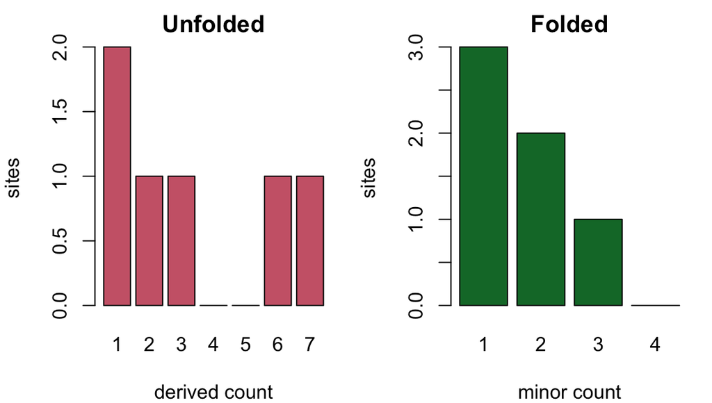

```r
par(mfrow = c(1, 2), mar = c(4, 4, 2, 1))
barplot(xi,  names.arg = 1:(n - 1), col = "#CC6677",
        xlab = "derived count", ylab = "sites", main = "Unfolded")
barplot(eta, names.arg = 1:(n %/% 2), col = "#117733",
        xlab = "minor count", ylab = "sites", main = "Folded")
```

Compare these to the tables you filled in by hand. Do they match? If so, you can make an SFS.